# Simulation Study

Simulation study to empirically make three points:

- When interested in causal interaction, we need to condition not only on $X$, but also on $T \times X$ (second-order estimand)
- Even with the correct conditioning set, linear models quickly collapse in settings of nonlinearity due to functional form violations
- Parallel estimation not neccessary for ATME. Idea: $T \perp (Y(1), Y(0), X, S)$ by design, since $T$ is randomized, so balancing within $T$ or across full sample will not make a significant difference since $T$ is randomly distributed anyways.

# Setup

```r
library(cobalt)
library(dplyr)
library(furrr)
library(future)
library(ggplot2)
library(progressr)
library(purrr)
library(tidymodels)
library(tidyr)

# for plots:
library(showtext)
library(sysfonts)

set.seed(42)

font_add(
  "Gyre",
  regular = "/usr/share/texmf/fonts/opentype/public/tex-gyre/texgyretermes-regular.otf"
)

showtext_auto()

theme_paper <- function(base_size = 14, base_family = "Gyre") {
  theme_minimal(base_size = base_size, base_family = base_family) +
    theme(
      panel.grid.major = element_line(color = "#E5E5E5", linewidth = 0.4),
      panel.grid.minor = element_blank(),

      axis.line = element_line(color = "black"),
      axis.ticks = element_line(color = "black"),

      axis.text = element_text(color = "black"),
      axis.title = element_text(color = "black"),

      plot.title = element_text(face = "bold", size = rel(1.2)),
      plot.subtitle = element_text(color = "black"),

      legend.position = "right",
      legend.title = element_text(face = "bold"),

      panel.background = element_blank(),
      plot.background = element_blank()
    )
}

theme_set(theme_paper())
```

# Data generating process

I simulated a scenario with a binary treatment $T_i \in \{0,1\}$, a binary moderator $S_i$, and one continuous covariate $X_i$. The treatment was randomized independently of all other covariates:

$$T_i \sim \text{Bernoulli}(0.5)$$

The moderator $S_i$ is not randomized, and is generated as a scenario-specific function $f(\cdot)$ of $X_i$:

$$\begin{aligned}
S_i \mid X_i &\sim \text{Bernoulli}(\text{logit}^{-1}(f(X_i))) \\
X_i &\sim \mathcal{N}(0, 1)
\end{aligned}$$

Potential outcomes satisfy

$$\begin{aligned}
Y_i(0) &\sim g(X_i) + \varepsilon_i, \ \varepsilon \sim \mathcal{N}(0, 0.5^2), \\
Y_i(1) &= Y_i(0) + h(X_i) + \theta S \\
Y_i(1) - Y_i(0) &= h(X_i) + \theta S
\end{aligned}$$

So that the treatment effect is a function of $X$ and $S$. $\theta$ is the strength of the true causal effect modification by $S$. The realized outcome is

$$Y_i = T_i Y_i(1) + (1 - T_i) Y_i(0).$$

I consider two settings, $\theta = 0$ (no causal effect modification by $S$) and $\theta=0.5$ (causal effect modification by $S$ with confounding by $X$).

First, for each setting, I test a linear scenario

$$f(x) = x, \ g(x) = x, \ h(x) = x$$

where selection into $S=1$ is caused linearly by $X$, and the treatment effect varies as a linear function of $X$.

Second, I also test a nonlinear scenario

$$f(x) = \begin{cases} 3 + 2 \sin(2x) - 1.5 \text{ if } x > 0 \\ 2\sin(2x) - 1.5 \text{ otherwise.} \end{cases}, \
g(x) = 0.3x - 0.2x^2, \
h(x) = \begin{cases} 0.5 + 0.3\sin(2x) \text{ if } x > 0 \\ 0.3\sin(2x) \text{ otherwise.} \end{cases}$$

where selection into $S$ and the treatment effect are affected by $X$ non-linearly. This causes a setting where the treatment is only really effective in a specific region of $X$.

```r
gen_data <- function(n, sel_fun, base_fun, het_fun, gamma = 0) {

  x <- rnorm(n)
  t <- rbinom(n, 1, .5)
  s <- rbinom(n, 1, plogis(sel_fun(x)))


  mu0 <- base_fun(x)             # baseline outcome
  tau <- het_fun(x) + gamma * s  # nonlinear effect heterogeneity

  # potential outcomes:
  Y0 <- mu0 + rnorm(n, sd = 0.5)
  Y1 <- Y0 + tau

  y <- ifelse(t == 1, Y1, Y0)

  tibble(x, t, s, y)

}

# couple of non-linear functions probably not well approximable:

f <- function(x) {
  3 * (x > 0) + 2 * sin(2 * x) - 1.5
}

g <- function(x) {
  0.3 * x - 0.2 * x^2
}

h <- function(x) {
  0.5 * (x > 0) + 0.3 * sin(2 * x)
}
```

Tuning procedure:

```r
get_weights <- function(d, deg_fr, clip = .025) {

  suppressWarnings(
    ps_mod <- glm(
      s ~ splines::ns(x, df = deg_fr),
      family = binomial(link = "logit"),
      data = d
    )
  )

  # propensity scores = predicted s=1 probabilities from X
  prop <- predict(ps_mod, type = "response")

  # clip extreme probabilities:
  prop <- pmin(pmax(prop, clip), 1 - clip)
  # calculate stabilized weights:
  pS <- mean(d$s)
  (d$s * pS / prop) + ((1 - d$s) * (1 - pS) / (1 - prop))
}

balance_stats <- function(formula, data, weights) {

  balance <- cobalt::bal.tab(
    formula,
    weights = weights,
    data = data,
    estimand = "ATE"
  )

  tibble(
    mean_asmd = mean(abs(balance$Balance$Diff.Adj)),
    max_asmd = max(abs(balance$Balance$Diff.Adj)),
    ess_treat = balance$Observations["Adjusted", ]$Treated,
    ess_cont = balance$Observations["Adjusted", ]$Control
  )
}

tune_deg_free <- function(formula, data, range) {

  map(range, function(df) {

    bal <- balance_stats(
      formula,
      data = data,
      weights = get_weights(
        d = data,
        deg_fr = df
      )
    )

    bal |> bind_cols(df = df)

  }) |> bind_rows()
}

pull_best_model <- function(tune_res, metric) {
  tune_res |>
    arrange({{ metric }}) |>
    slice(1) |>
    pull(df) |>
    _[[1]]
}
```

# Models

Linear models; one deliberately misspecified (not accounting for $T \times X$):

```r
linear_est <- function(d) {
  coef(lm(y ~ t*s + t*x, data = d))["t:s"]
}

linear_est_misspec <- function(d) {
  coef(lm(y ~ t*s + x, data = d))["t:s"]
}
```

Inverse probability weighting, where the propensity score model can account for nonlinearity:

```r
ipw_est <- function(d, clip = 0.025) {

  best_df <-
    tune_deg_free(s ~ x, data = d, range = 1:10) |>
    pull_best_model(mean_asmd)

  ps_mod <- glm(
    s ~ splines::ns(x, df = best_df),
    family = binomial(link = "logit"),
    data = d
  )

  # propensity scores = predicted s=1 probabilities from X
  prop <- predict(ps_mod, type = "response")

  # clip extreme probabilities:
  prop <- pmin(pmax(prop, clip), 1 - clip)
  # calculate stabilized weights:
  pS <- mean(d$s)
  ipw <- (d$s * pS / prop) + ((1 - d$s) * (1 - pS) / (1 - prop))

  coef(lm(y ~ t*s + t*x, data = d, weights = ipw))["t:s"]
}
```

The same thing in the “parallel estimation framework” (Bansak 2021):

```r
ipw_par_est <- function(d, clip = 0.025) {
  d |>
    group_by(t) |>
    nest() |>
    ungroup() |>
    mutate(
      estim = map_dbl(data, function(d) {

        best_df <-
          tune_deg_free(s ~ x, data = d, range = 1:10) |>
          pull_best_model(mean_asmd)

        ps_mod <- glm(
          s ~ splines::ns(x, df = best_df),
          family = binomial(link = "logit"),
          data = d
        )

        # propensity scores = predicted s=1 probabilities from X
        prop <- predict(ps_mod, type = "response")

        # clip extreme probabilities:
        prop <- pmin(pmax(prop, clip), 1 - clip)
        # calculate stabilized weights:
        pS <- mean(d$s)
        ipw <- (d$s * pS / prop) + ((1 - d$s) * (1 - pS) / (1 - prop))

        coef(lm(y ~ s, data = d, weights = ipw))["s"]

      })
    ) |>
    select(-data) |>
    pivot_wider(names_from = t, values_from = estim) |>
    mutate(final = `1` - `0`) |>
    pull(final)
}
```

# Simulation

Laying out the scenarios & procedure; parallelizing over all but one available cores to speed this up:

```r
scenarios <- tribble(
  ~scenario,   ~sel_fun, ~base_fun, ~het_fun,
  "Linear",    \(x) x,   \(x) x,    \(x) x,
  "Nonlinear", f,        g,         h
)

# Procedure:

monte_carlo <- function(times, n, ...) {

  plan(multisession, workers = parallel::detectCores() - 1)

  suppressWarnings({

    with_progress({

      p <- progressor(steps = times)

      future_map(1:times, function(i) {

        p()

        df <- gen_data(n, ...)

        tribble(
          ~model,             ~est,                   ~run,
          "Linear",           linear_est(df),         i,
          "Linear, misspec.", linear_est_misspec(df), i,
          "IPW",              ipw_est(df),            i,
          "IPW, Parallel",    ipw_par_est(df),        i
        )

      }, .options = furrr_options(seed = 42))

    })

  })

}
```

# First setting: no true causal moderation by $S$

```r
sim_res <- pmap(scenarios, function(scenario, sel_fun, base_fun, het_fun) {

  message(paste0("Working on ", scenario))

  res <- monte_carlo(
    times = 500, # originally: 1000
    n = 2500,
    sel_fun = sel_fun,
    base_fun = base_fun,
    het_fun = het_fun
  )

  res |> bind_rows() |> mutate(scenario = scenario)

}) |> bind_rows()
```

## Results

```r
sim_res |>
  group_by(model, scenario) |>
  summarise(
    mean = mean(est),
    lower = quantile(est, .025),
    upper = quantile(est, .975)
  ) |>
  ungroup() |>
  arrange(scenario, model) |>
  select(
    scenario, model, estimate = mean,`2.5%` = lower, `97.5%` = upper
  ) |>
  rename_with(stringr::str_to_title) |>
  knitr::kable(format = "latex")
```

Visually:

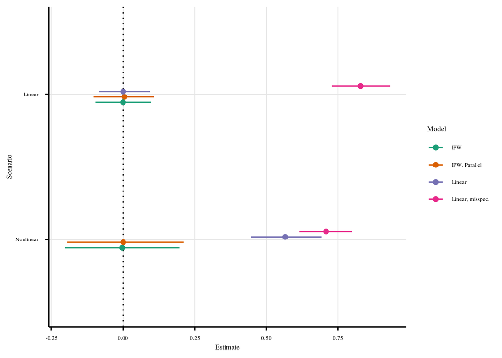

```r
sim_res |>
  mutate(scenario = factor(scenario, levels = c("Nonlinear", "Linear"))) |>
  group_by(model, scenario) |>
  summarise(
    mean = mean(est),
    lower = quantile(est, .025),
    upper = quantile(est, .975)
  ) |>
  ggplot(aes(x = mean, y = scenario, color = model)) +
  geom_vline(xintercept = 0, lty = "dotted") +
  geom_point(position = position_dodge(width = .15)) +
  geom_linerange(
    aes(xmin = lower, xmax = upper),
    position = position_dodge(width = .15)
  ) +
  labs(
    x = "Estimate",
    y = "Scenario",
    color = "Model"
  ) +
  scale_color_brewer(palette = "Dark2")
```

```r
#ggsave(here::here("figs/sim_res.pdf"), width = 7, height = 5)
```

Distributions:

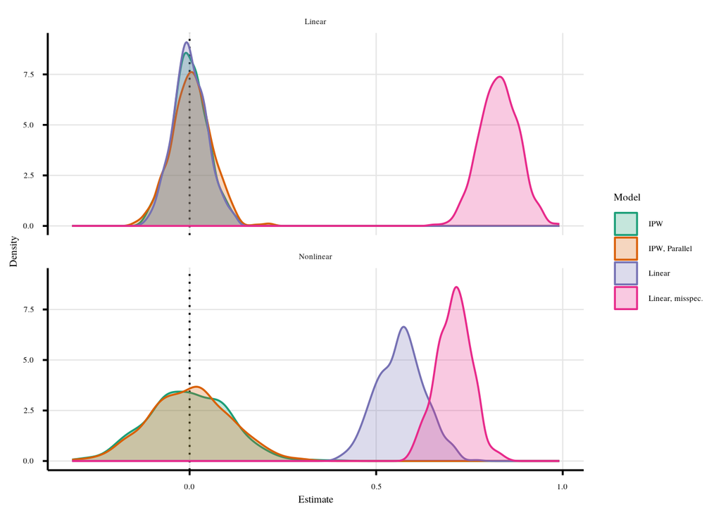

```r
sim_res |>
  group_by(model, scenario) |>
  ggplot(aes(x = est, color = model, fill = model)) +
  geom_vline(xintercept = 0, lty = "dotted") +
  geom_density(alpha = .25) +
  facet_wrap(~scenario, ncol = 1) +
  labs(
    x = "Estimate",
    y = "Density",
    color = "Model",
    fill = "Model"
  ) +
  scale_color_brewer(palette = "Dark2") +
  scale_fill_brewer(palette = "Dark2")
```

```r
#ggsave(here::here("figs/sim_res_dist.pdf"), width = 7, height = 5)
```

# Second setting: true (confounded) causal effect moderation by $S$

Here, $S$ is actually an effect modifier:

```r
scenarios2 <- tribble(
  ~scenario,   ~sel_fun, ~base_fun, ~het_fun, ~gamma,
  "Linear",    \(x) x,   \(x) x,    \(x) x,   .5,
  "Nonlinear", f,        g,         h,        .5
)
```

Running again:

```r
sim_res2 <- pmap(scenarios2, function(scenario, sel_fun, base_fun, het_fun, gamma) {

  message(paste0("Working on ", scenario))

  res <- monte_carlo(
    times = 1000,
    n = 2500,
    sel_fun = sel_fun,
    base_fun = base_fun,
    het_fun = het_fun,
    gamma = gamma
  )

  res |> bind_rows() |> mutate(scenario = scenario)

}) |> bind_rows()
```

## Results

```r
sim_res2 |>
  group_by(model, scenario) |>
  summarise(
    mean = mean(est),
    lower = quantile(est, .025),
    upper = quantile(est, .975)
  ) |>
  ungroup() |>
  arrange(scenario, model) |>
  select(
    scenario, model, estimate = mean,`2.5%` = lower, `97.5%` = upper
  ) |>
  rename_with(stringr::str_to_title) |>
  knitr::kable(format = "latex")
```

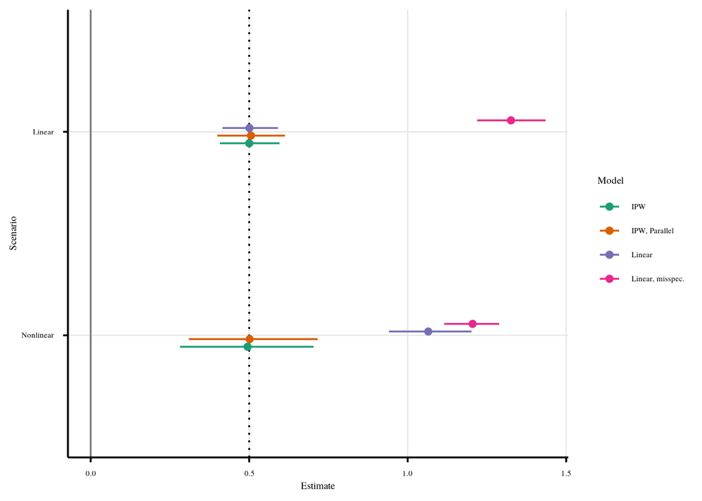

```r
sim_res2 |>
  mutate(scenario = factor(scenario, levels = c("Nonlinear", "Linear"))) |>
  group_by(model, scenario) |>
  summarise(
    mean = mean(est),
    lower = quantile(est, .025),
    upper = quantile(est, .975)
  ) |>
  ggplot(aes(x = mean, y = scenario, color = model)) +
  geom_vline(xintercept = 0, color = "grey50") +
  geom_vline(xintercept = 0.5, lty = "dotted") +
  geom_point(position = position_dodge(width = .15)) +
  geom_linerange(
    aes(xmin = lower, xmax = upper),
    position = position_dodge(width = .15)
  ) +
  labs(
    x = "Estimate",
    y = "Scenario",
    color = "Model"
  ) +
  scale_color_brewer(palette = "Dark2")
```

```r
#ggsave(here::here("figs/sim_res2.pdf"), width = 7, height = 5)
```

Distributions:

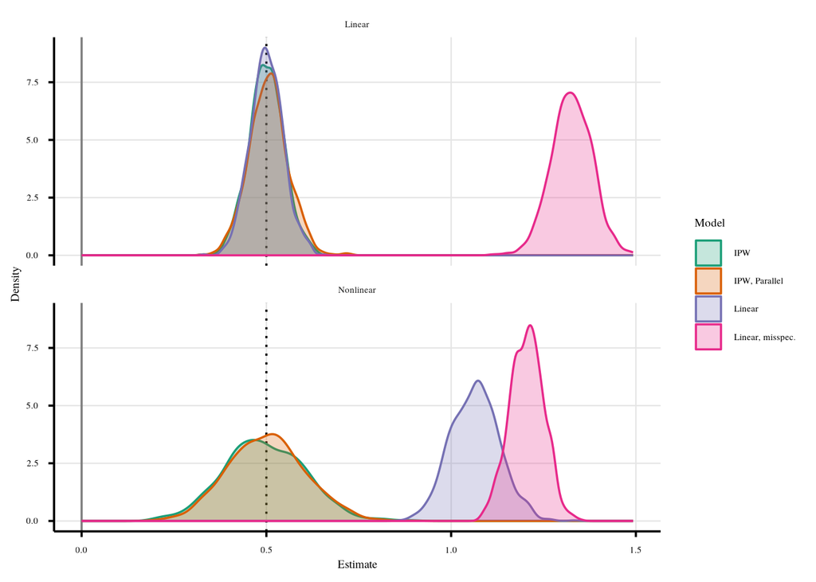

```r
sim_res2 |>
  group_by(model, scenario) |>
  ggplot(aes(x = est, color = model, fill = model)) +
  geom_vline(xintercept = 0, color = "grey50") +
  geom_vline(xintercept = .5, lty = "dotted") +
  geom_density(alpha = .25) +
  facet_wrap(~scenario, ncol = 1) +
  labs(
    x = "Estimate",
    y = "Density",
    color = "Model",
    fill = "Model"
  ) +
  scale_color_brewer(palette = "Dark2") +
  scale_fill_brewer(palette = "Dark2")
```

```r
#ggsave(here::here("figs/sim_res2_dist.pdf"), width = 7, height = 5)
```

# Additional stuff

## Visualizations of the scenarios:

### Linear

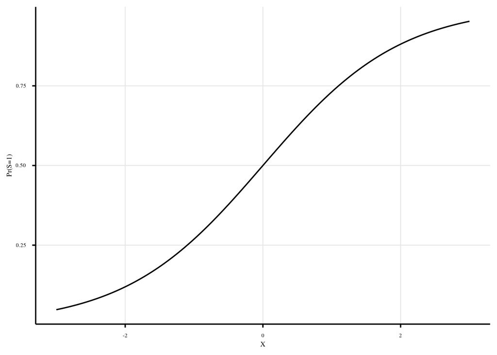

```r
tibble(x = seq(-3, 3, length.out = 500)) |>
  mutate(y = plogis(x)) |>
  ggplot(aes(x = x, y = y)) +
  geom_line() +
  labs(x = "X", y = "Pr(S=1)")
```

```r
#ggsave(here::here("figs/sim_funs_f_linear.pdf"), width = 7, height = 5)
```

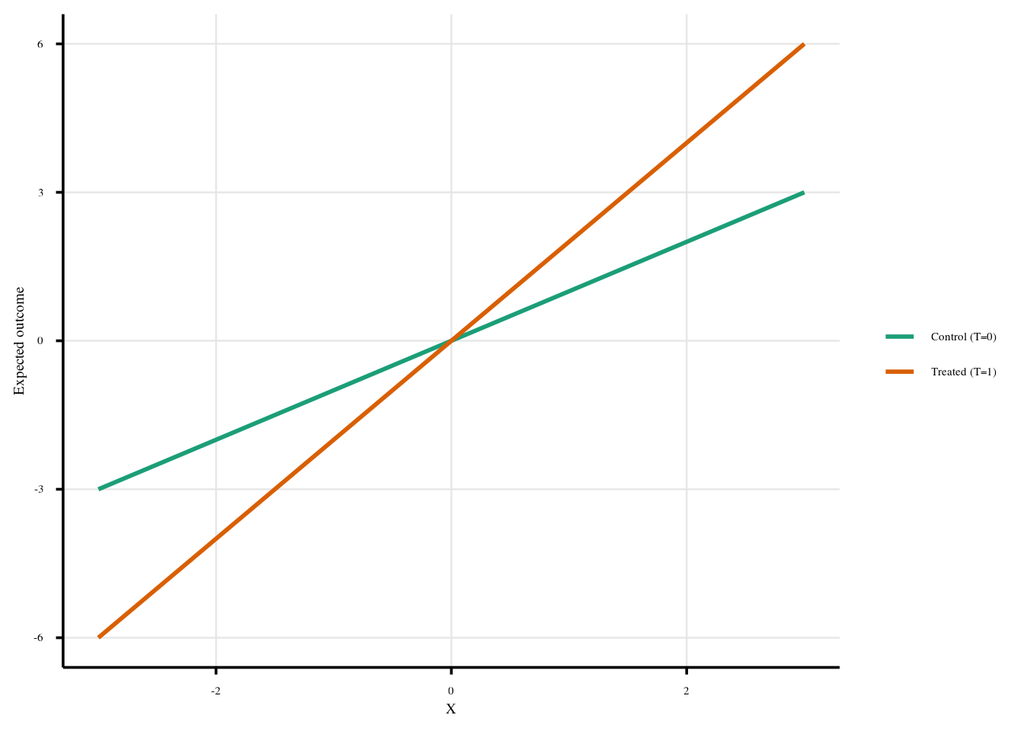

```r
tibble(x = seq(-3, 3, length.out = 500)) |>
  mutate(
    Y0 = x,
    Y1 = x + x
  ) |>
  pivot_longer(c(Y0, Y1), names_to = "treatment", values_to = "Ey") |>
  mutate(
    treatment = treatment |> replace_values(
      "Y0" ~ "Control (T=0)",
      "Y1" ~ "Treated (T=1)"
    )
  ) |>
  ggplot(aes(x = x, y = Ey, color = treatment)) +
  geom_line(linewidth = 1) +
  labs(
    x = "X",
    y = "Expected outcome",
    color = ""
  ) +
  scale_color_brewer(palette = "Dark2")
```

```r
#ggsave(here::here("figs/sim_funs_Ey_linear.pdf"), width = 7, height = 5)
```

### Nonlinear:

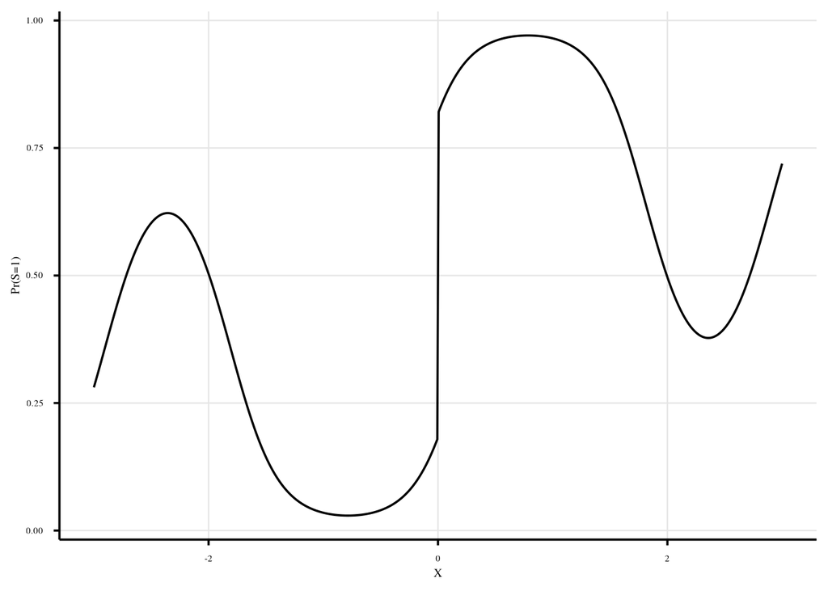

```r
tibble(x = seq(-3, 3, length.out = 500)) |>
  mutate(y = plogis(f(x))) |>
  ggplot(aes(x = x, y = y)) +
  geom_line() +
  labs(x = "X", y = "Pr(S=1)")
```

```r
#ggsave(here::here("figs/sim_funs_f.pdf"), width = 7, height = 5)
```

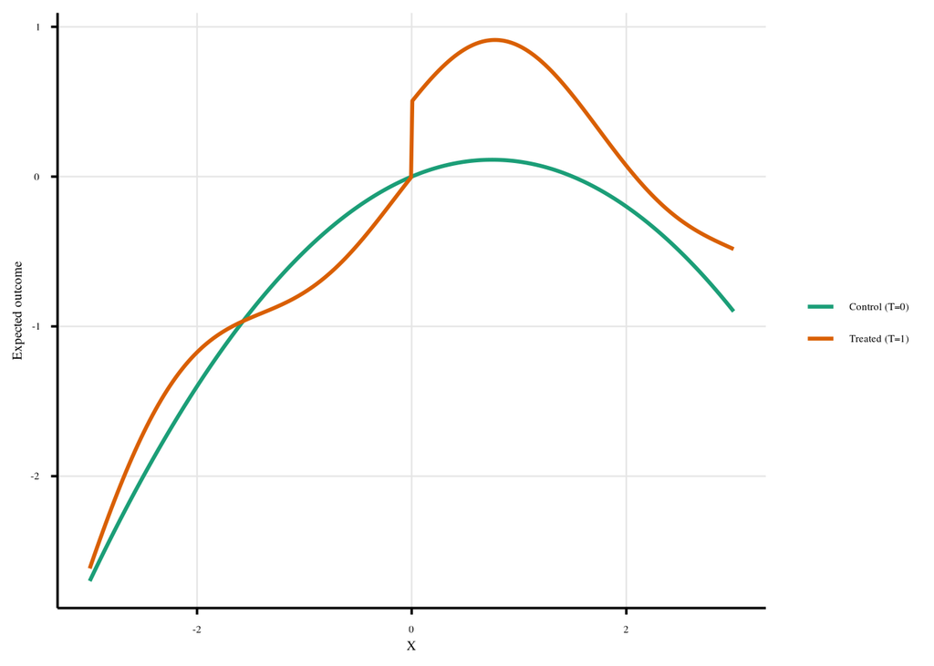

```r
tibble(x = seq(-3, 3, length.out = 500)) |>
  mutate(
    Y0 = g(x),
    Y1 = g(x) + h(x)
  ) |>
  pivot_longer(c(Y0, Y1), names_to = "treatment", values_to = "Ey") |>
  mutate(
    treatment = treatment |> replace_values(
      "Y0" ~ "Control (T=0)",
      "Y1" ~ "Treated (T=1)"
    )
  ) |>
  ggplot(aes(x = x, y = Ey, color = treatment)) +
  geom_line(linewidth = 1) +
  labs(
    x = "X",
    y = "Expected outcome",
    color = ""
  ) +
  scale_color_brewer(palette = "Dark2")
```

```r
#ggsave(here::here("figs/sim_funs_Ey.pdf"), width = 7, height = 5)
```